# Final Project: R Code

Peter Harrison, Evan Nagesh, Katherine Rodriguez, and Sophia Tejeda

2024-12-13

## Set Up

```r
library(gtsummary)
library(ggplot2)
library(dplyr)
library(magrittr)
library(here) # edited
```

We have included the link to the data we used, the download includes red wine, white wine and a what is basically a “readme” file. You don’t have to download it we just included if you actually planned on running any of the code. We focused our analysis on the red wine dataset.

UC Irvine Machine Learning Repository (CSVs were downloaded from here): https://archive.ics.uci.edu/dataset/186/wine+quality

```r
red <- read.csv("redwine.csv", sep = ",") #edited title of original file, not renamed
```

## EDA

```r
summary(red)
```

```
##  fixed.acidity   volatile.acidity  citric.acid    residual.sugar
##  Min.   : 4.60   Min.   :0.1200   Min.   :0.000   Min.   : 0.900
##  1st Qu.: 7.10   1st Qu.:0.3900   1st Qu.:0.090   1st Qu.: 1.900
##  Median : 7.90   Median :0.5200   Median :0.260   Median : 2.200
##  Mean   : 8.32   Mean   :0.5278   Mean   :0.271   Mean   : 2.539
##  3rd Qu.: 9.20   3rd Qu.:0.6400   3rd Qu.:0.420   3rd Qu.: 2.600
##  Max.   :15.90   Max.   :1.5800   Max.   :1.000   Max.   :15.500
##    chlorides       free.sulfur.dioxide total.sulfur.dioxide    density
##  Min.   :0.01200   Min.   : 1.00       Min.   :  6.00       Min.   :0.9901
##  1st Qu.:0.07000   1st Qu.: 7.00       1st Qu.: 22.00       1st Qu.:0.9956
##  Median :0.07900   Median :14.00       Median : 38.00       Median :0.9968
##  Mean   :0.08747   Mean   :15.87       Mean   : 46.47       Mean   :0.9967
##  3rd Qu.:0.09000   3rd Qu.:21.00       3rd Qu.: 62.00       3rd Qu.:0.9978
##  Max.   :0.61100   Max.   :72.00       Max.   :289.00       Max.   :1.0037
##        pH          sulphates         alcohol         quality
##  Min.   :2.740   Min.   :0.3300   Min.   : 8.40   Min.   :3.000
##  1st Qu.:3.210   1st Qu.:0.5500   1st Qu.: 9.50   1st Qu.:5.000
##  Median :3.310   Median :0.6200   Median :10.20   Median :6.000
##  Mean   :3.311   Mean   :0.6581   Mean   :10.42   Mean   :5.636
##  3rd Qu.:3.400   3rd Qu.:0.7300   3rd Qu.:11.10   3rd Qu.:6.000
##  Max.   :4.010   Max.   :2.0000   Max.   :14.90   Max.   :8.000
```

```r
head(red)
```

```
##   fixed.acidity volatile.acidity citric.acid residual.sugar chlorides
## 1           7.4             0.70        0.00            1.9     0.076
## 2           7.8             0.88        0.00            2.6     0.098
## 3           7.8             0.76        0.04            2.3     0.092
## 4          11.2             0.28        0.56            1.9     0.075
## 5           7.4             0.70        0.00            1.9     0.076
## 6           7.4             0.66        0.00            1.8     0.075
##   free.sulfur.dioxide total.sulfur.dioxide density   pH sulphates alcohol
## 1                  11                   34  0.9978 3.51      0.56     9.4
## 2                  25                   67  0.9968 3.20      0.68     9.8
## 3                  15                   54  0.9970 3.26      0.65     9.8
## 4                  17                   60  0.9980 3.16      0.58     9.8
## 5                  11                   34  0.9978 3.51      0.56     9.4
## 6                  13                   40  0.9978 3.51      0.56     9.4
##   quality
## 1       5
## 2       5
## 3       5
## 4       6
## 5       5
## 6       5
```

```r
## one in presentation cuts out Chlorides and Sulphates variables and circles pH in slides
red %>%
  select(quality, alcohol, pH,  sulphates, residual.sugar, chlorides) %>%
  tbl_summary(
    by = quality,
     digits = list(
 all_continuous() ~ c(2,2)
 ),
 statistic = all_continuous() ~ "{mean}({sd})",
 label = list(residual.sugar ~ "Residual Sugar",
              sulphates ~ "Sulphates",
              alcohol ~ "Alcohol (%)",
              chlorides ~ "Chlorides")
  )%>%

modify_header(label = "**Variable**")%>%
bold_labels()
```

| **Variable** | **3** N = 10<sup>1</sup> | **4** N = 53<sup>1</sup> | **5** N = 681<sup>1</sup> | **6** N = 638<sup>1</sup> | **7** N = 199<sup>1</sup> | **8** N = 18<sup>1</sup> |
| --- | --- | --- | --- | --- | --- | --- |
| Alcohol (%) | 9.96(0.82) | 10.27(0.93) | 9.90(0.74) | 10.63(1.05) | 11.47(0.96) | 12.09(1.22) |
| pH | 3.40(0.14) | 3.38(0.18) | 3.30(0.15) | 3.32(0.15) | 3.29(0.15) | 3.27(0.20) |
| Sulphates | 0.57(0.12) | 0.60(0.24) | 0.62(0.17) | 0.68(0.16) | 0.74(0.14) | 0.77(0.12) |
| Residual Sugar | 2.64(1.40) | 2.69(1.79) | 2.53(1.36) | 2.48(1.44) | 2.72(1.37) | 2.58(1.30) |
| Chlorides | 0.12(0.07) | 0.09(0.08) | 0.09(0.05) | 0.08(0.04) | 0.08(0.03) | 0.07(0.01) |

<sup>1</sup> Mean(SD)

## Data Manipulation

### Preping Data for Analysis and Beginning Visualiations

To prepare for a chi-squared test for independence, we needed to turn acidity and quality ratings into categorical variables. We did that by setting splitting each into groups based on the distribution of the data.

```r
red <- red %>%
  mutate(ph_level = case_when(pH < 3.2 ~ 'Low',
                               pH < 3.4 ~ 'Medium',
                               pH < 4.05 ~ 'High'))
```

Make categorical variables factors.

```r
#Create a new variable quality_rate
red$quality_rate <- ifelse(red$quality >=6 , "High", "Low")

#Make categorical variables factors.
red <- red %>%
  mutate_if(is.character, as.factor)
```

#### Correlation Heatmaps

Let’s look at a heatmap to see which variable have the strongest correlation with one another.

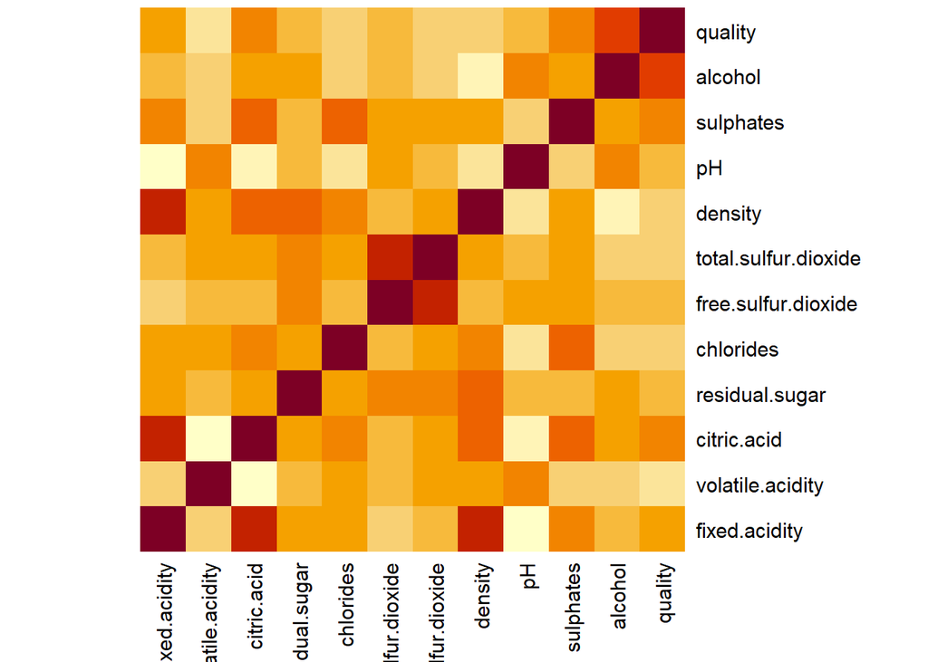

```r
subset <- red %>%
  select(-ph_level, -quality_rate)
heatmap(cor(subset), symm = TRUE, Rowv = NA, Colv = NA)
```

#### pH

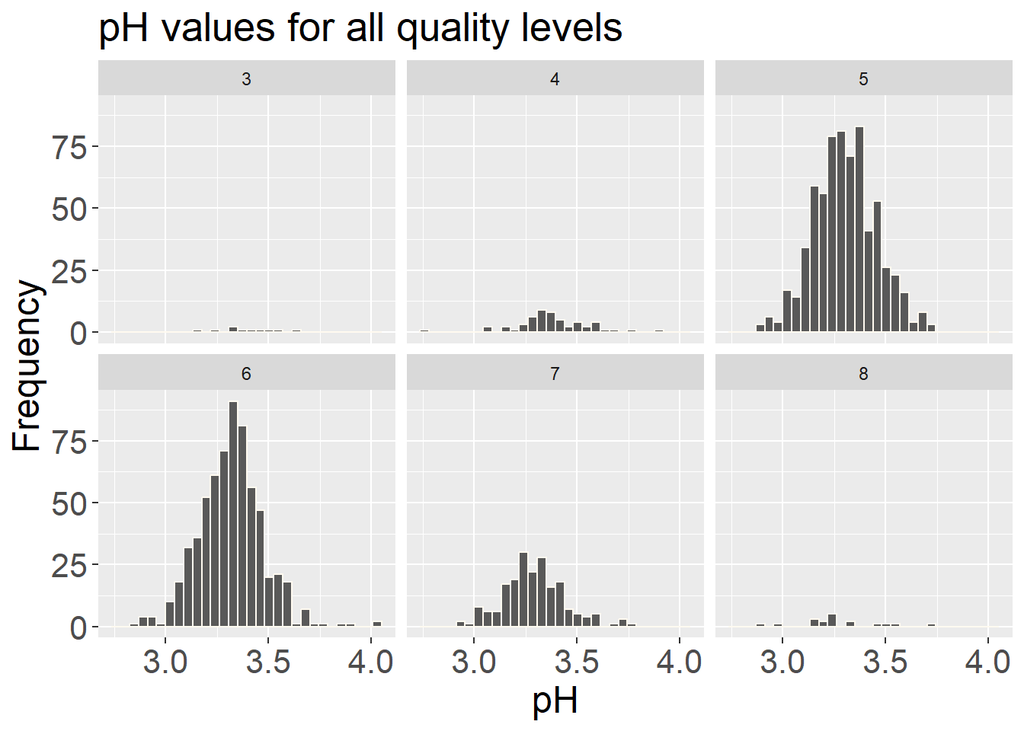

```r
red %>%
  ggplot(aes(x = pH)) +
  geom_histogram(col = "floralwhite") +
  labs(title = "pH values for all quality levels",
       x = "pH",
       y = "Frequency") +
  theme(axis.text = element_text(size = 16),
        axis.title = element_text(size = 18),
        plot.title = element_text(size = 20)) +
  facet_wrap(~ quality)
```

#### higher alcohol gets a better rating?

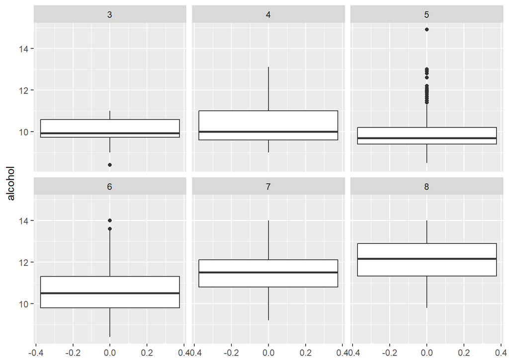

```r
ggplot(red, aes( y = alcohol)) +
  geom_boxplot() +
  facet_wrap(~quality)
```

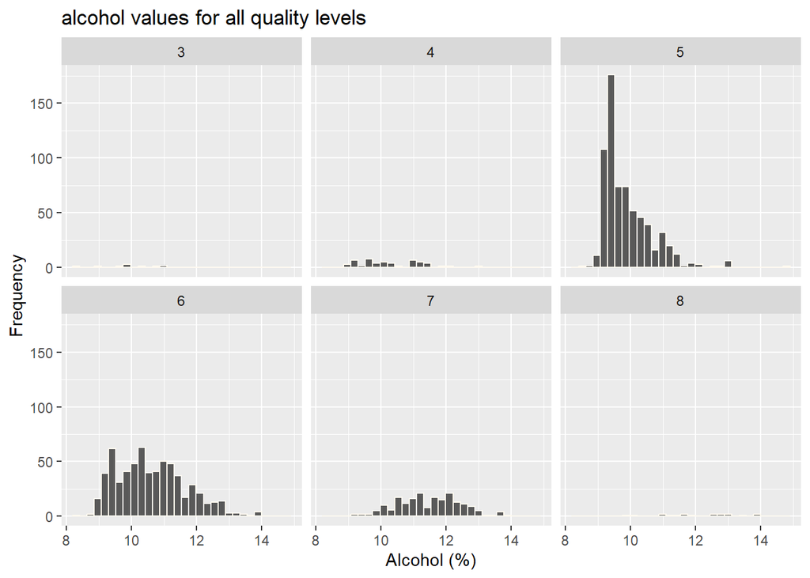

```r
red %>%
  ggplot(aes(x = alcohol)) +
  geom_histogram(col = "floralwhite") +
  labs(title = "alcohol values for all quality levels",
       x = "Alcohol (%)",
       y = "Frequency") +
  facet_wrap(~ quality)
```

```r
  theme(axis.text = element_text(size = 16))
```

[output not shown]

# A/B Testing

Chi-Squared test - quality and pH

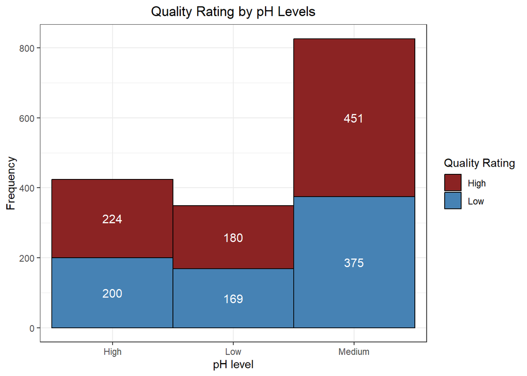

```r
red %>%
  ggplot(aes(x = ph_level, fill = quality_rate))+
  geom_bar(width = 1, color = 'black')+
  stat_count(geom = 'text', color = 'white', size = 4,
             aes(label = ..count.., group = quality_rate), position = position_stack(vjust=0.5))+
  labs(title = "Quality Rating by pH Levels",
       x = "pH level",
       y = "Frequency") +
  theme_bw() +
  theme(plot.title = element_text(hjust = 0.5)) +
  scale_fill_manual('Quality Rating', values = c('brown4', 'steelblue'))
```

```r
#Test association using quality rating levels (low and high) vs pH levels (low, medium, and high)
table_wine_quality <- table(red$ph_level,
                            red$quality_rate)

test_wine <- chisq.test(table_wine_quality)
test_wine
```

```
##
##  Pearson's Chi-squared test
##
## data:  table_wine_quality
## X-squared = 0.9973, df = 2, p-value = 0.6074
```

```r
#expected counts conditions
expected <- round(test_wine$expected,2)
expected
```

```
##
##            High    Low
##   High   226.72 197.28
##   Low    186.61 162.39
##   Medium 441.67 384.33
```

Decision: We fail to reject $H_0$, the null hypothesis.

Conclusion: We do not have enough evidence to conclude that pH level is associated with quality rating. We don’t have evidence to state pH level and quality rating are dependent of one another.

## 2 Means test - Low vs High Quality Wines

2 means Test

```r
lowquality <- red %>% filter(quality < 6)
highquality <- red %>% filter(quality > 5)

pH_only_lowqual <- lowquality %>% select(pH)
pH_only_highqual <- highquality %>% select(pH)

red_2means <- t.test(pH_only_lowqual, pH_only_highqual)
red_2means
```

```
##
##  Welch Two Sample t-test
##
## data:  pH_only_lowqual and pH_only_highqual
## t = 0.13045, df = 1567.3, p-value = 0.8962
## alternative hypothesis: true difference in means is not equal to 0
## 95 percent confidence interval:
##  -0.01417561  0.01619551
## sample estimates:
## mean of x mean of y
##  3.311653  3.310643
```